# Who’s that Pokémon?

A research on the most competitive Pokémon // A.Y. 2025-2026

Maria Briones

Riccardo Dondi

Sayantan Mandal

## Our mission: catch them all!

Our main goal is to provide some insights on the Pokémon world to help parents to advice their children on how to catch them all.

[figure not shown]

POKEDEX of Sinnoh region

## The data

- We will be using the [Pokémon](https://github.com/rfordatascience/tidytuesday/blob/main/data/2025/2025-04-01/readme.md) dataset, which contains information about 949 pokemons on 22 variables.
- DATA CLEANING: We removed NA values from generation as they belonged to special edition pokemons and discarded irrelevant variables like color, height and egg group, among others.

## Our Variables

- **id** and **pokemon**: the id (num) and name (chr) of the Pokémon.
- **type_1** and **type_2**: the primary and secondary type of the Pokémon (chr).
- **hp**: the health points of the Pokémon (num).
- **attack**: the attack points of the Pokémon (num).
- **defense**: the defense points of the Pokémon (num).
- **special_attack**: the special attack points of the Pokémon (num).
- **special_defense**: the special defense points of the Pokémon (num).
- **speed**: the speed points of the Pokémon (num).
- **generation_id**: the generation on wich the Pokémon was introduced (num).

## The insights

We worked mainly on 3 insights:

1. **Pokémon distribution by generation** (table)
2. **Number of Pokemons by type and generation** (table)
3. **Stats of Dual-type vs Single-type Pokemons** (table)

[figure not shown]

## 1. Distribution by generation

- We want to understand:
  - Which generation has the most pokemons?
  - Which generation has the most powerful pokemons?
- A table should be sufficient to answer these questions.

## 1. Distribution by generation

Table 1: Pokemon average stats by generation

| Generation | Count | HP | C. Attack | C. Defense | Speed |
| --- | --- | --- | --- | --- | --- |
| 1 | 151 | 64.21 | 140.05 | 134.31 | 69.07 |
| 2 | 100 | 70.98 | 132.76 | 142.03 | 61.41 |
| 3 | 135 | 65.67 | 140.97 | 135.47 | 61.61 |
| 4 | 107 | 73.10 | 153.50 | 149.68 | 69.48 |
| 5 | 156 | 70.31 | 150.28 | 138.57 | 66.60 |
| 6 | 72 | 68.92 | 145.04 | 149.94 | 65.68 |
| 7 | 81 | 70.69 | 156.68 | 151.89 | 64.54 |

### 1. Outcome

- The most populated generations are **the 1st, 3rd and 5th**, highlighted in blue in the table.
- Nevertheless, the most powerfull generation considering all four stats (combined attack, combined defense, hp and speed) is **the 4th generation**.

[figure not shown]

The starters of 4th gen

## 2. Number of Pokemons by type and generation

Are some types or combination of types more common than others?

Table 2: Number of Pokemons by type and generation

| Primary type | Gen 1 | Gen 2 | Gen 3 | Gen 4 | Gen 5 | Gen 6 | Gen 7 | Total |
| --- | --- | --- | --- | --- | --- | --- | --- | --- |
| Bug | 12 | 10 | 12 | 8 | 18 | 3 | 9 | 72 |
| Dragon | 3 | 0 | 7 | 3 | 7 | 4 | 3 | 27 |
| Electric | 9 | 6 | 4 | 7 | 7 | 3 | 3 | 39 |
| Fairy | 2 | 5 | 0 | 1 | 0 | 9 | 1 | 18 |
| Fighting | 7 | 2 | 4 | 2 | 7 | 3 | 4 | 29 |
| Fire | 12 | 8 | 6 | 5 | 8 | 8 | 5 | 52 |
| Ghost | 3 | 1 | 4 | 6 | 5 | 4 | 4 | 27 |
| Grass | 12 | 9 | 12 | 13 | 15 | 5 | 12 | 78 |
| Ground | 8 | 3 | 6 | 4 | 9 | 0 | 2 | 32 |
| Ice | 2 | 4 | 6 | 3 | 6 | 2 | 0 | 23 |
| Normal | 22 | 15 | 18 | 17 | 17 | 4 | 12 | 105 |
| Poison | 14 | 1 | 3 | 6 | 2 | 2 | 4 | 32 |
| Psychic | 8 | 7 | 8 | 7 | 14 | 3 | 6 | 53 |
| Rock | 9 | 4 | 8 | 6 | 6 | 8 | 4 | 45 |
| Water | 28 | 18 | 24 | 13 | 17 | 5 | 9 | 114 |
| Dark | 0 | 5 | 4 | 3 | 13 | 3 | 1 | 29 |
| Steel | 0 | 2 | 9 | 3 | 4 | 4 | 2 | 24 |
| Flying | 0 | 0 | 0 | 0 | 1 | 2 | 0 | 3 |

## 3. Dual vs Single type Pokemons

Does dual type Pokémon performes better than single type?

- To answer this question, we should look at the average power stats of both single and dual type pokemons.

$power = hp + attack + defense + sp.attack + sp.defense + speed$

[figure not shown]

### 3a. Category comparison

Summary Power Statistics by Dual-Type Status

| Is Dual? | Count | Mean Power | Median Power | Power SD |
| --- | --- | --- | --- | --- |
| FALSE | 400 | 403.8 | 405 | 109.8 |
| TRUE | 402 | 438.4 | 460 | 109.3 |

Dual-type Pokémon average **438.4** power stats vs **403.8** for single-types — a ~35-point (8.56%) gap.

### 3b. Most powerfull primary types

Table 3: Mean Power Stats by Primary Type and Dual-Type Status

| Primary Type | Is Dual? | Count | Mean Power |
| --- | --- | --- | --- |
| Dragon | TRUE | 15 | 568.0 |
| Fire | TRUE | 22 | 490.5 |
| Psychic | TRUE | 18 | 484.4 |
| Steel | TRUE | 20 | 477.9 |
| Fighting | TRUE | 7 | 469.7 |
| Electric | TRUE | 12 | 463.2 |
| Rock | TRUE | 34 | 450.4 |
| Dark | TRUE | 20 | 447.3 |
| Ground | TRUE | 17 | 440.7 |
| Ice | FALSE | 12 | 438.6 |

### 3b. Most powerfull primary types

Dragon dual-types lead all groups at 568 power average. Fire types follows far behind with and average of 490.5 on power stats.

[figure not shown]

[figure not shown]

## Visualizations :

[figure not shown]

The previous insights are complemented by graph analysis.

- **Type proportion on the 7 generations** (heatmap)
- **Distribution of stats by type** (bar + line plot)
- **Single vs Dual-type stat distributions** (violin - plot)

## Type proportion

- Considering the 18 main types and the 19 secondary types (including “None”), there are **342 possible combinations** of types.
- Which combinations of types are more common and which are more rare?
- To better understand the proportion of types we can use a heatmap: the more intense the color, the more pokemons of that type combination there are.

## Type proportion

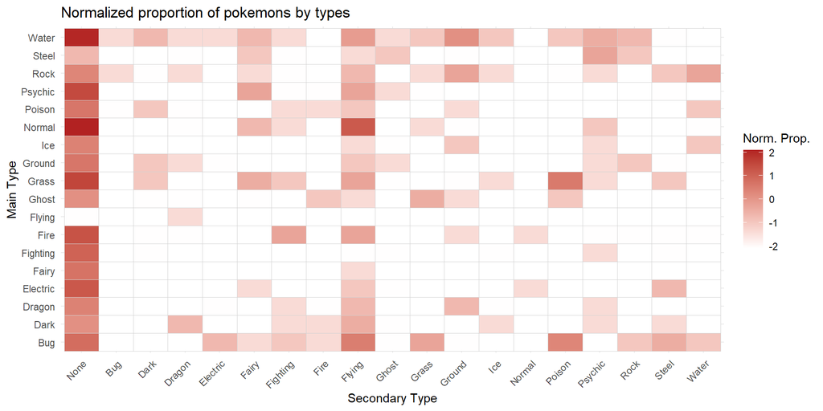

Normalized proportion of pokemons by types

### Outcome

Assuming that each pokémon species distributed homogeneously across the world (strong assumption), we could say that the most abuntant pokemons belong to the **Water-None** combination.

For Double-type, the most common combinations are: **Normal-Flying** (like Pidgey), **Grass-Poison** (like Bulbasaur), **Bug-Flying** (like Butterfree).

[figure not shown]

Squirtle gang

## Distribution of stats by type

To have a even more clear view on the Pokémon world, we analyzed also the distribution of stats grouped by type to see which are the most or less effective ones.

- We used a bar-plot for the combined attack and defense stats overlaped by a line plot for the health-points and speed.

## Distribution of stats by type

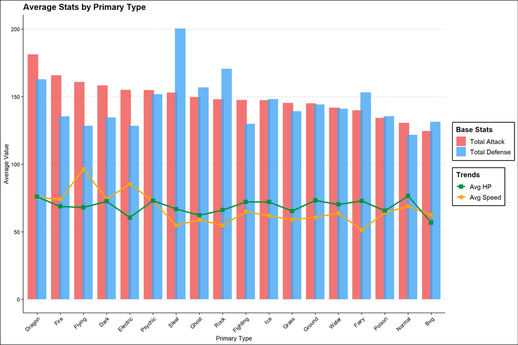

Average Stats by Primary Type

## Single vs Dual type stats distribution

Coming back to the Dual-type analysis, we perform a violin chart to visualize the distribution of our summarising power stat across the different primary type categories.

## Single vs Dual type stats distribution

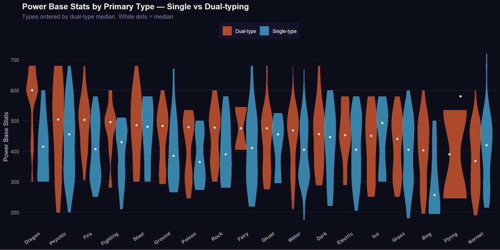

Power Base Stats by Primary Type — Single vs Dual-typing

## Conclusion

Some battle-tested advice:

- Dual-type Pokémon are worth the extra effort (Dragon-dual-types are the best ones);
- The 4th generation is a goldmine of powerful Pokemons, so consider focusing on the Sinnoh region;
- Always keep an eye on the types synergy and on their rareness.

## Who’s our Pokémon?

The most competitive Pokémon is **Garchomp**: a Dragon-Ground dual-type from the 4th generation with a stat power of 608 points, 130 attack and 95 defense, but…

[figure not shown]

## Who’s our Pokémon?

At the end, our choice was, is and will always be **Pikachu ⚡**!

[figure not shown]

The best pokemon ever